# Прогнозирование заказов такси

## Анализ

```python
taxi = taxi.sort_index()
taxi=taxi.resample('1H').sum()
```

*Построим графики временного ряда. Разложим данные на три составляющие: тренд, сезонность и остаток.*

```python
def line_decompose(file, title, xlabel, ylabel):
    ax = file.plot(kind='line', grid=False, color='blue', figsize=(30,8), ax=plt.gca())
    ax.set_xlabel(xlabel, fontsize=16, fontweight="bold", color='blue')
    ax.set_ylabel(ylabel, fontsize=16, fontweight="bold", color='blue')
    ax.set_title(title, fontsize=16, fontweight="bold", color='blue')
```

```python
decomposed = seasonal_decompose(taxi)
```

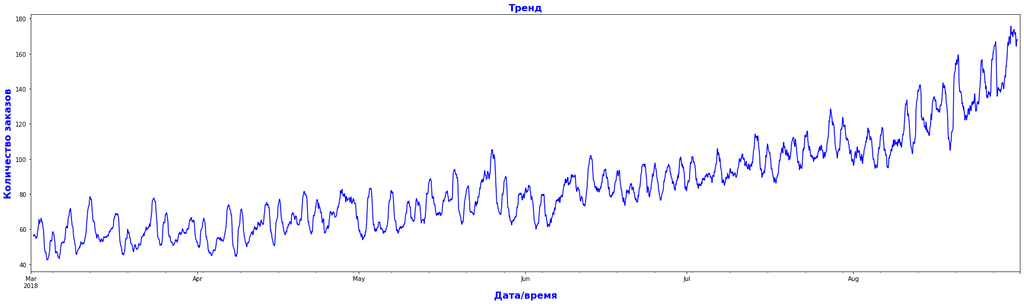

```python
file=decomposed.trend
title='Тренд'
xlabel='Дата/время'
ylabel='Количество заказов'
line_decompose(file, title, xlabel, ylabel)
```

*Наблюдаем тренд к росту количества заказов такси к концу лета. Видимо к окончанию отпускного периода летом активнее всего пользуются услугами такси.*

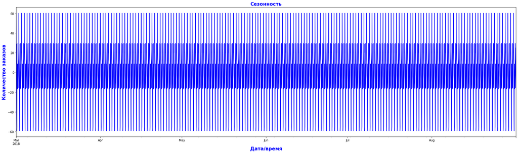

```python
file=decomposed.seasonal
title='Сезонность'
xlabel='Дата/время'
ylabel='Количество заказов'
line_decompose(file, title, xlabel, ylabel)
```

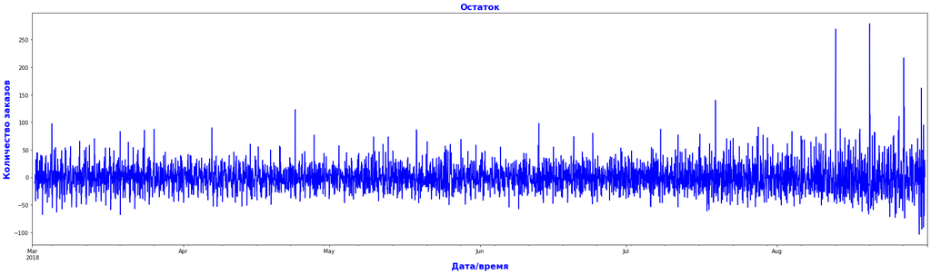

```python
file=decomposed.resid
title='Остаток'
xlabel='Дата/время'
ylabel='Количество заказов'
line_decompose(file, title, xlabel, ylabel)
```

*Построим графики последнего месяца временного ряда (август). Разложим также данные на три составляющие: тренд, сезонность и остаток.*

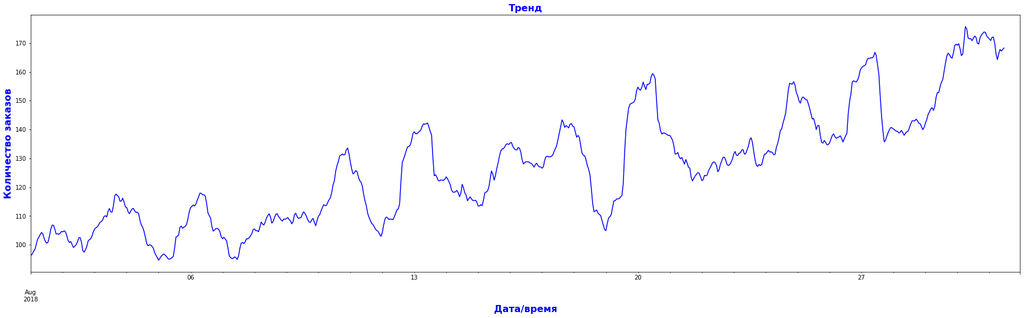

```python
file=decomposed.trend['2018-08':'2018-08']
title='Тренд'
xlabel='Дата/время'
ylabel='Количество заказов'
line_decompose(file, title, xlabel, ylabel)
```

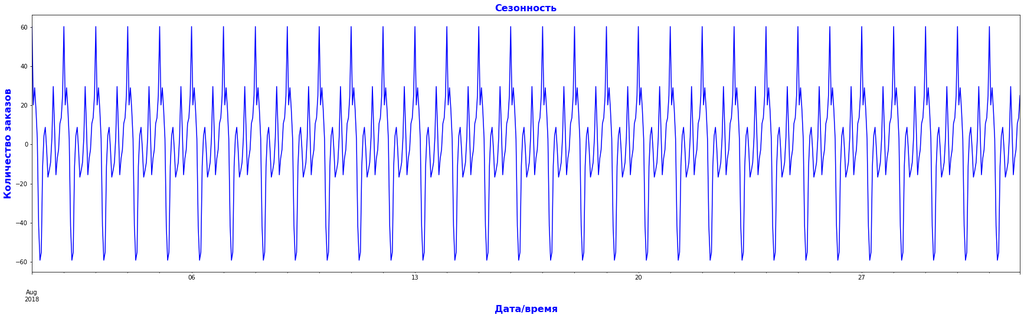

```python
file=decomposed.seasonal['2018-08':'2018-08']
title='Сезонность'
xlabel='Дата/время'
ylabel='Количество заказов'
line_decompose(file, title, xlabel, ylabel)
```

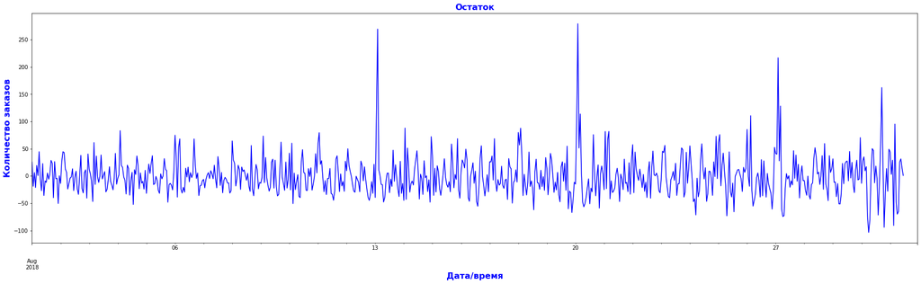

```python
file=decomposed.resid['2018-08':'2018-08']
title='Остаток'
xlabel='Дата/время'
ylabel='Количество заказов'
line_decompose(file, title, xlabel, ylabel)
```

*Построим график временного ряда на неделю начиная с понедельника 20 августа 2018 года. Разложим также данные на три составляющие: тренд, сезонность и остаток.*

```python
df = taxi['2018-08-20':'2018-08-27']
df['dayofweek'] = df.index.day_name()
df['dayofweek'].unique()
print(*df['dayofweek'].unique(), sep="\n")
```

```
Monday
Tuesday
Wednesday
Thursday
Friday
Saturday
Sunday
```